# Análisis y Pronóstico de Series Temporales con ARIMA

## 6.5 Descomposición de la Serie

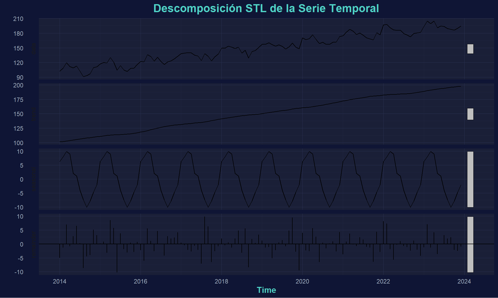

```r
decomp <- stl(serie_ts, s.window = "periodic")

autoplot(decomp) +
  labs(title = "Descomposición STL de la Serie Temporal") +
  theme_vision()
```

## 6.6 Análisis de Componentes

```r
tendencia_comp <- decomp$time.series[, "trend"]
estacional_comp <- decomp$time.series[, "seasonal"]
residuos_comp <- decomp$time.series[, "remainder"]

cat("Fuerza de la Estacionalidad:\n")
```

```
## Fuerza de la Estacionalidad:
```

```r
fuerza_estacional <- 1 - var(residuos_comp) / var(estacional_comp + residuos_comp)
cat(sprintf("F_S = %.4f\n", fuerza_estacional))
```

```
## F_S = 0.7587
```

```r
cat("\nFuerza de la Tendencia:\n")
```

```
##
## Fuerza de la Tendencia:
```

```r
fuerza_tendencia <- 1 - var(residuos_comp) / var(tendencia_comp + residuos_comp)
cat(sprintf("F_T = %.4f\n", fuerza_tendencia))
```

```
## F_T = 0.9815
```

# 7 Resultados del Modelo ARIMA

## 7.1 Verificación de Estacionariedad

```r
adf_result <- adf.test(serie_ts)
cat("Test ADF (Augmented Dickey-Fuller):\n")
```

```
## Test ADF (Augmented Dickey-Fuller):
```

```r
cat(sprintf("Estadístico: %.4f\n", adf_result$statistic))
```

```
## Estadístico: -8.7770
```

```r
cat(sprintf("p-valor: %.4f\n", adf_result$p.value))
```

```
## p-valor: 0.0100
```

```r
kpss_result <- kpss.test(serie_ts)
cat("\nTest KPSS:\n")
```

```
##
## Test KPSS:
```

```r
cat(sprintf("Estadístico: %.4f\n", kpss_result$statistic))
```

```
## Estadístico: 2.4064
```

```r
cat(sprintf("p-valor: %.4f\n", kpss_result$p.value))
```

```
## p-valor: 0.0100
```

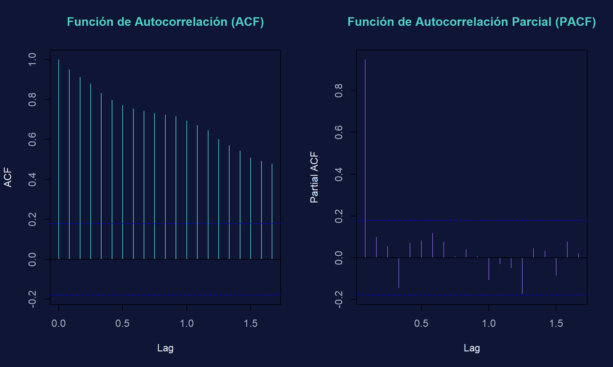

```r
par(mfrow = c(1, 2), bg = "#0F1535", col.main = "#4FD1C5",
    col.lab = "#e0e6ed", col.axis = "#A0AEC0")
acf(serie_ts, main = "Función de Autocorrelación (ACF)", col = "#4FD1C5")
pacf(serie_ts, main = "Función de Autocorrelación Parcial (PACF)", col = "#805AD5")
```

```r
par(mfrow = c(1, 1))
```